# Coursera Regression Quiz 4

This is Quiz 4 from Coursera’s Regression Models class within the Data Science Specialization. This publication is intended as a learning resource, all answers are documented and explained. Datasets are available in R packages.

### Question 1.

Consider the space shuttle data in the {MASS} library. Consider modeling the use of the autolander as the outcome (variable name use). Fit a logistic regression model with autolander (variable auto) use (labeled as “auto” 1) versus not (0) as predicted by wind sign (variable wind).

Give the estimated odds ratio for autolander use comparing head winds, labeled as “head” in the variable headwind (numerator) to tail winds (denominator).

*0.969*

#### Explanation:

```r
library(MASS)
data(shuttle)
head(shuttle) %>% kable()
```

| stability | error | sign | wind | magn | vis | use |
| --- | --- | --- | --- | --- | --- | --- |
| xstab | LX | pp | head | Light | no | auto |
| xstab | LX | pp | head | Medium | no | auto |
| xstab | LX | pp | head | Strong | no | auto |
| xstab | LX | pp | tail | Light | no | auto |
| xstab | LX | pp | tail | Medium | no | auto |
| xstab | LX | pp | tail | Strong | no | auto |

```r
library(janitor)
shuttle %>% tabyl(use,wind) %>% kable()
```

| use | head | tail |
| --- | --- | --- |
| auto | 72 | 73 |
| noauto | 56 | 55 |

```r
#Creating 0,1 variable for auto/noauto factor
shuttle$use <- as.numeric(shuttle$use == "auto")
```

```r
#generating model
model <- glm(factor(use)~factor(wind)-1,binomial,data = shuttle)
```

```r
exp(model$coef[1])/exp(model$coef[2])
```

```
## factor(wind)head
##        0.9686888
```

```r
exp(coef(model))
```

```
## factor(wind)head factor(wind)tail
##         1.285714         1.327273
```

### Question 2.

Consider the previous problem. Give the estimated odds ratio for autolander use comparing head winds (numerator) to tail winds (denominator) adjusting for wind strength from the variable magn.

*0.969*

#### Explanation:

```r
#Checking out the factor levels
unique(shuttle$magn)
```

```
## [1] Light  Medium Strong Out
## Levels: Light Medium Out Strong
```

```r
model2 <- glm(factor(use)~factor(wind)+factor(magn)-1,
              family = binomial,
              data = shuttle)
summary(model2)
```

```
##
## Call:
## glm(formula = factor(use) ~ factor(wind) + factor(magn) - 1,
##     family = binomial, data = shuttle)
##
## Deviance Residuals:
##    Min      1Q  Median      3Q     Max
## -1.349  -1.321   1.015   1.040   1.184
##
## Coefficients:
##                      Estimate Std. Error z value Pr(>|z|)
## factor(wind)head    3.635e-01  2.841e-01   1.280    0.201
## factor(wind)tail    3.955e-01  2.844e-01   1.391    0.164
## factor(magn)Medium -1.010e-15  3.599e-01   0.000    1.000
## factor(magn)Out    -3.795e-01  3.568e-01  -1.064    0.287
## factor(magn)Strong -6.441e-02  3.590e-01  -0.179    0.858
##
## (Dispersion parameter for binomial family taken to be 1)
##
##     Null deviance: 354.89  on 256  degrees of freedom
## Residual deviance: 348.78  on 251  degrees of freedom
## AIC: 358.78
##
## Number of Fisher Scoring iterations: 4
```

```r
coef(model2)
```

```
##   factor(wind)head   factor(wind)tail factor(magn)Medium    factor(magn)Out
##       3.635093e-01       3.955180e-01      -1.009525e-15      -3.795136e-01
## factor(magn)Strong
##      -6.441258e-02
```

```r
exp(model2$coef[1])/exp(model2$coef[2])
```

```
## factor(wind)head
##        0.9684981
```

### Question 3.

If you fit a logistic regression model to a binary variable, for example use of the autolander, then fit a logistic regression model for one minus the outcome (not using the autolander) what happens to the coefficients?

*The coefficients reverse their signs.*

#### Explanation:

The sign of the ceofficient flips. One minus a binary variable flips zeros with 1 and vice versa.

```r
model3 <- glm(1-use~factor(wind)-1,binomial,data = shuttle)
model3$coef
```

```
## factor(wind)head factor(wind)tail
##       -0.2513144       -0.2831263
```

```r
model$coef
```

```
## factor(wind)head factor(wind)tail
##        0.2513144        0.2831263
```

### Question 4.

Consider the insect spray data. Fit a Poisson model using spray as a factor level.

Report the estimated relative rate comapring spray A (numerator) to spray B (denominator).

*0.9457*

#### Explanation:

```r
data("InsectSprays")
model4 <- glm(count~spray-1,poisson,data = InsectSprays)
exp(model4$coef[1])/exp(model4$coef[2])
```

```
##    sprayA
## 0.9456522
```

### Question 5

Consider a Poisson glm with an offset, t. So, for example, a model of the form `glm(count ~ x + offset(t), family = poisson)` where X is a factor variable comparing a treatment (1) to a control (0) and `t` is the natural log of a monitoring time.

What is impact of the coefficient for 𝚡 if we fit the model `glm(count ~ x + offset(t2), family = poisson)` where 𝟸 <- 𝚕𝚘𝚐(𝟷𝟶) + 𝚝?

In other words, what happens to the coefficients if we change the units of the offset variable. (**Note, adding log(10) on the log scale is multiplying by 10 on the original scale.**)

*The coefficient estimate is unchanged*

#### Explanation:

Coefficient stays because poisson regression is modeling odds so the multiplicative offset will cancel out.

```r
model5 <- glm(count~spray,poisson,offset = log(count+1),data = InsectSprays)
model6 <- glm(count~spray,poisson,
              offset = log(10)+log(count+1),data = InsectSprays)
```

```r
model5$coef
```

```
##  (Intercept)       sprayB       sprayC       sprayD       sprayE       sprayF
## -0.066691374  0.003512473 -0.325350713 -0.118451059 -0.184623054  0.008422466
```

```r
model6$coef
```

```
##  (Intercept)       sprayB       sprayC       sprayD       sprayE       sprayF
## -2.369276467  0.003512473 -0.325350713 -0.118451059 -0.184623054  0.008422466
```

#### Question 6

Consider the data

```r
x <- -5:5
y <- c(5.12, 3.93, 2.67, 1.87, 0.52, 0.08, 0.93, 2.05, 2.54, 3.87, 4.97)
```

Using a knot point at 0, fit a linear model that looks like a hockey stick with two lines meeting at x=0. Include an intercept term, $X$ and the knot point term. What is the estimated slope of the line after 0?

*1.013*

#### Explanation:

To give the coefficients R automatically subtracted the mean slope of the first line from that of the second, so we can simply add it back to get the true value.

[output not shown]

```r
k<-c(0)
split<-sapply(k,function(k) (x>k)*(x-k))
xmat<-cbind(1,x,split)
model7 <- lm(y~xmat-1)
yhat<-predict(model7)
model7$coef
```

```
##       xmat      xmatx       xmat
## -0.1825806 -1.0241584  2.0372258
```

```r
model7$coef[3]+model7$coef[2]
```

```
##     xmat
## 1.013067
```

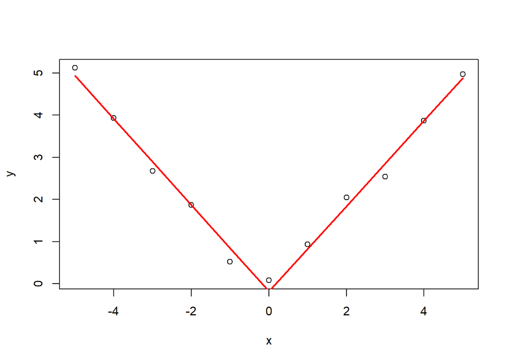

```r
plot(x,y)
lines(x,yhat, col= "red", lwd =2)
```